# Chapter 7 End of Chapter Questions

Currently, the questions come from the 6th edition of the QC book. Different version have the same problems but different numbers.

## Problem 7.1: Nonconforming Bearings

The data in Table 7E.1 give the number of nonconforming bearing and seal assemblies in samples of size 100. Construct a fraction nonconforming control chart for these data. If any points plot out of control, assume that assignable causes can be found and determine the revised control limits.

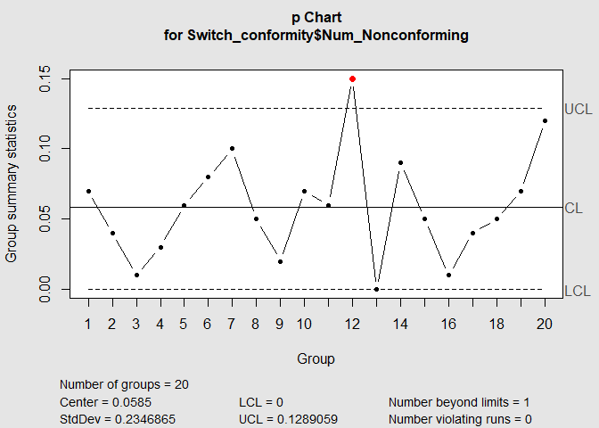

```r
library(qcc)
Switch_conformity <- read.csv("Switch_conformity.csv")

Switch_chart <- qcc(Switch_conformity$Num_Nonconforming, sizes = Switch_conformity$Size, type = 'p')
```

In this case, sample 12 is beyond the control limit. Let’s remove it and try again.

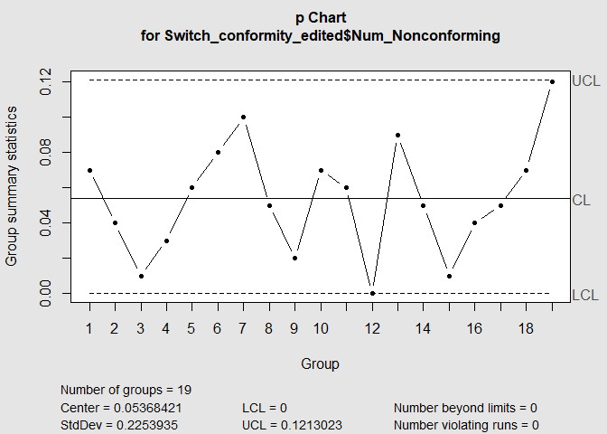

```r
Switch_conformity_edited <- Switch_conformity[-c(12),]

Switch_chart_edited <- qcc(Switch_conformity_edited$Num_Nonconforming, sizes = Switch_conformity_edited$Size, type = 'p')
```

## Problem 7.6: np Chart

Based on the data in Table 7E.6 if an np chart is to be established, what would you recommend as the center line and control limits? Assume that n = 500

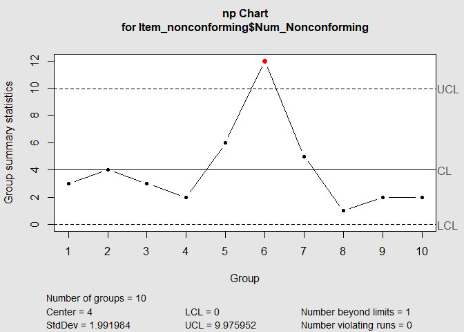

```r
#the data can be read from the chart
Item_nonconforming <- read.csv("Item_nonconforming.csv")
Item_chart <- qcc(Item_nonconforming$Num_Nonconforming, sizes = Item_nonconforming$Size, type = 'np')
```

## Problem 7.21: Maintenance Repair

A maintenance group improves the effectiveness of its repair work by monitoring the number of maintenance requests that require a second call to complete the repair. Twenty weeks of data are shown in Table 7E.8.  
Create a control chart for controlling future production.

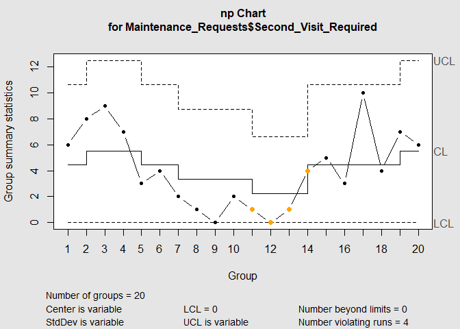

```r
Maintenance_Requests <- read.csv("Maintenance_Requests.csv")

Maintenance_chart <- qcc(Maintenance_Requests$Second_Visit_Required, sizes = Maintenance_Requests$Requests, type = 'np')
```

## Problem 7.23: Standardized Maintenance Repair Chart

Use the data from problem 7.21 above to create a standardized chart for the data

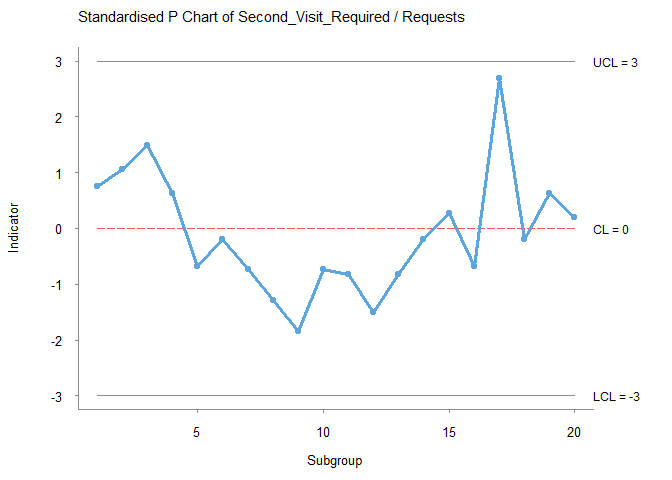

```r
#use the data from the previous problem to make the standardized chart
#the qicharts library has a function called qic, which allows us to make a standardised charts more easily
#if you haven't already, run ** install.packages("qicharts") ** to install the package

library(qicharts)
qic(data = Maintenance_Requests,
    n = Requests,
    y = Second_Visit_Required,
    chart = 'p',
    standardised = T
    )
```

## Problem 7.67:

The data in Table 7E.19 are the number of information errors found in customer records in a marketing company database. Five records were sampled each day.  
Set up a c chart for the total number of errors. Is the process in control?

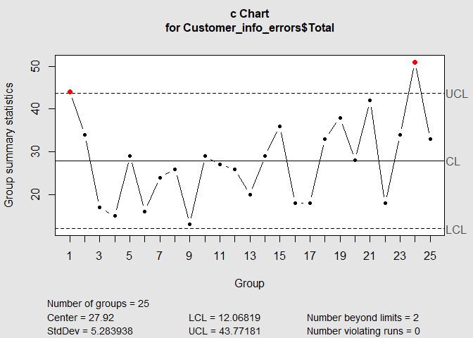

[output not shown]

```r
Customer_info_errors <- read.csv("Customer_info_errors.csv") #read the data into R

Customer_info_errors$Total <- rowSums(Customer_info_errors[,2:6]) #sum the errors, without including the sample number

qcc(Customer_info_errors$Total, type = 'c')
```